# EEMB146 Lab 3 Exercise

Written by Samantha Sambado

2024-01-02

## Exercise 3 - Visualizing Data & Identifying Distributions

# Learning Objectives

- Know what data types are meant for each graph
  - 1 numeric = **histogram**
  - 1 numeric, 1 factor = **boxplot**
  - 2 numeric = **scatterplot**
- Know how to improve graphs with **informative labels**
  - using `labs()` & `ggtitle()` functions
- Learn tricks to making more **visually appealing graphs**
  - alpha for transparency
  - fill to distinguish groups
  - `theme_*()` to change background
    - theme_bw()
    - theme_light()
    - theme_classic()
  - `theme()` to change text (axis titles & texts), rectangle (facet_wrap), and legend features
    - theme(axis.text = element_text())
    - theme(strip.background = element_rect())
    - theme(legend.position = “bottom”)
- **Identify data distribution** types

# Background

You can spend hours making pretty plots in R. When you are publishing papers you may want to do just that. In this class, we are not going to worry about publication quality figures, but we are going to learn how to make figures that tell you and anyone exactly what the data are showing. This tutorial will show you some examples of making figures in R. There is no way a tutorial can tell you everything you need to know about plotting in R, so we are just going to cover the basics. I would recommend playing around with some of the code as you work through this tutorial.

Also, if you have a question about how to make certain plots check out [The R gallery websites](http://r-graph-gallery.com/). Websites like these give you examples of how to make plots in R with all of the code included! If you get really excited about plotting in R, check out the package ggplot2. This package offers lots of options for customizing graphs and figures - see the [ggplot 2 Cheat Sheet](https://www.datacamp.com/cheat-sheet/ggplot2-cheat-sheet). The basic format of code in ggplot is always the same: we start by using the ggplot function to specify what data to use, and which variable to put on which axis. Then, we add on a “geom” using the plus sign to specify what kind of plot we want. There are a ton of other functions that can be added from there to customize the plot.

Note: You will see two ways to pass data through the `ggplot()` function.

- nest data into the `ggplot()` function = ggplot(**data**,…)
- or pipe data into `ggplot()` function = **data** %>% ggplot(aes(…))

I prefer piping data into `ggplot()` because it allows for better data manipulation without altering the data set. Some helpful ways to manipulate data prior to piping into ggplot involve `filter()` to a specific subgroup(s) or `mutate()` to create numeric summaries for groups. However, either nesting or piping data in ggplot works.

# Exercises

```r
## setting up the style of your knitted document
knitr::opts_chunk$set(echo = TRUE,message=FALSE, warning=FALSE)

################################################################################
## installing packages
#install.packages("cowplot")
library(cowplot) # NEW package for combining plots
#install.packages("plyr")
library(plyr) # NEW package for data wrangling, specifically the revalue() function
library(readr) # package for reading in data
library(tidyverse) # package for data wrangling
library(ggplot2) # package for plotting



################################################################################
## upload data
# recommend putting data into a folder called 'data'
knz_bison <- read.csv("data/knz_bison.csv")
vertebrates <- read.csv("data/and_vertebrates.csv")

#Data not uploading/getting  error messages? Are your csv  files in your Rproj folder?? Look at your files at the bottom right
```

## Exercise 0: Layers of a ggplot

We will be exploring the data set `knz_bison`. This data looks at Bison (*Bison bison*) herd information at the Konza Prairie Biological Station LTER, which is part of The [National Science Foundation’s (NSF) Long Term Ecological Research (LTER)](https://lternet.edu/) program. More details about specific columns can be found on the [ltersampler website](https://lter.github.io/lterdatasampler/reference/knz_bison.html).

**Some questions we can answer with the following code**:

- **Of the 3 plots, which plot begins to actually show the relationship between bison weight and year of birth? What functions/layers make that plot visually better?**

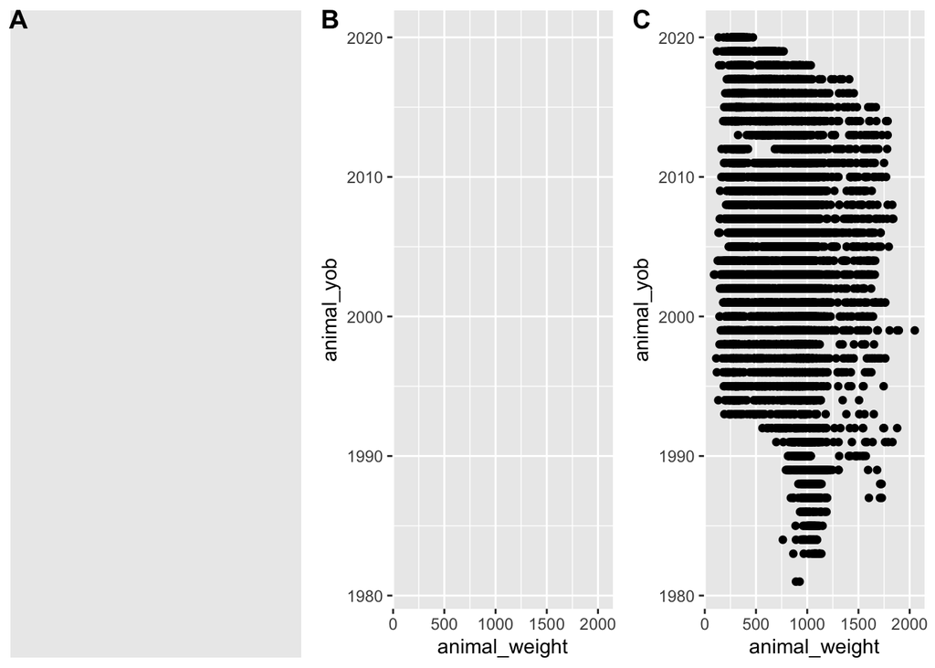

```r
ggplot1 <- ggplot() # plot A

ggplot2 <- ggplot(knz_bison, aes(x = animal_weight, y = animal_yob)) # plot B

ggplot3 <- ggplot(knz_bison, aes(x = animal_weight, y = animal_yob)) + # plot C
  geom_point()

plot_grid(ggplot1, ggplot2, ggplot3, # call all plots
          ncol = 3, # put plots in 3 columns
          labels = "AUTO") # add labels to plots # plot C is best plot because it has labels and data. The layers necessary to make plot c is ggplot() + aes(data) + geom_point()
```

## Exercise 1: Histogram

A **histogram** is a graphical representation of the distribution of a **numeric** variable. The variable is cut into several bins, and the number of observations per bin is represented by the height (i.e. frequency).

**Some questions we can answer with the following code**:

- **Based on the histogram, what is the distribution of `animal_weight` for all bison? (i.e. is it symmetrical/normally distributed?)**

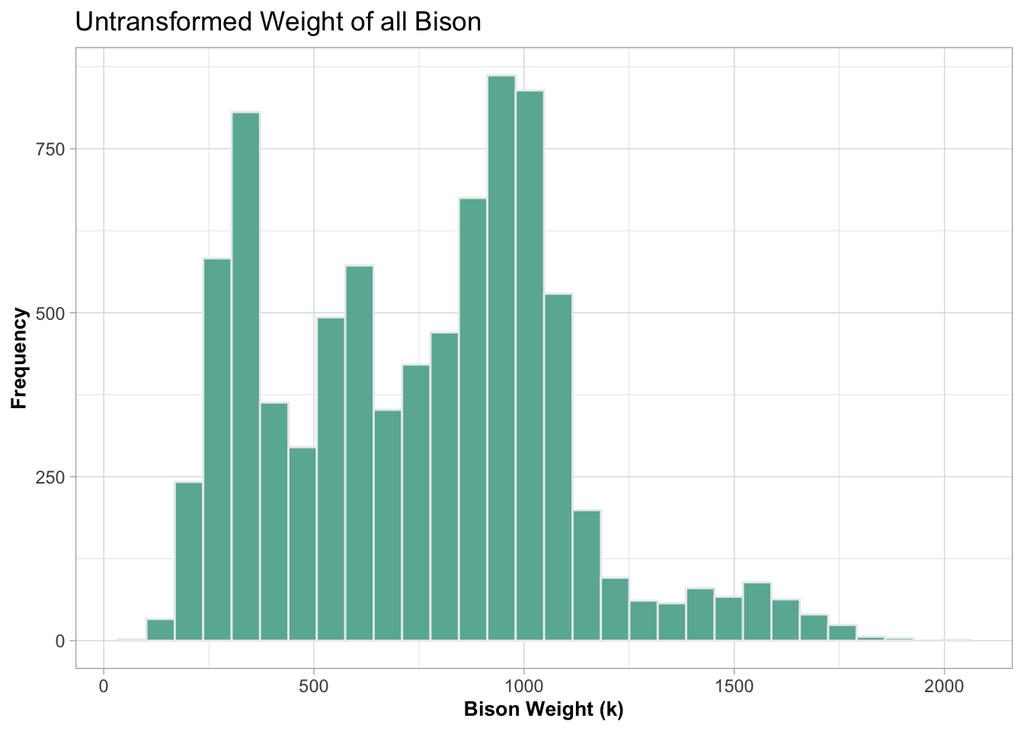

```r
hist <- knz_bison %>% # call in data set and then,
  ggplot(aes(x = animal_weight)) + # with the animal weight data
  geom_histogram(color = "#e9ecef", fill = "#69b3a2", position = "identity") + # create a histogram with color and fill
  theme_light() + # change the background to light theme
  labs(x = "Bison Weight (k)", y = "Frequency") + # create unique labels
  ggtitle("Untransformed Weight of all Bison") + # give plot a title
  theme(axis.title = element_text(size = 10, face = "bold")) # The distribution of all bison looks slightly right skewed.

hist
```

- **Based on the histograms, does a log or square root transformation of `animal_weight` improve the normal distribution?**

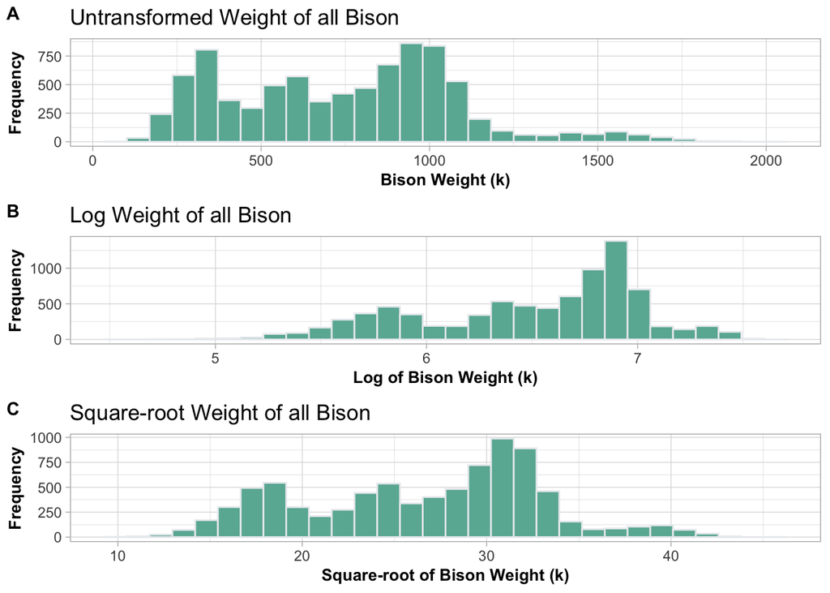

```r
# note: because the previous histogram shows there are no bison with weight = 0 k,
# I do not have to add +1 to the log transformation

log_hist <- knz_bison %>%  # call in data set and then,
  mutate(log_weight = log(animal_weight)) %>%  # create a new column called `log_weight` with the log of animal weight
  ggplot(aes(x = log_weight)) + # with the LOG of animal weight data
  geom_histogram(color = "#e9ecef", fill = "#69b3a2", position = "identity") +
  theme_light() +
  labs(x = "Log of Bison Weight (k)", y = "Frequency") + # NOTE: I add LOG of Bison Weight bc that is what I'm displaying
  ggtitle("Log Weight of all Bison") +
  theme(axis.title = element_text(size = 10, face = "bold")) # The distribution of all bison looks slightly left skewed.


sqrt_hist <- knz_bison %>%  # call in data set and then,
  mutate(sqrt_weight = sqrt(animal_weight)) %>%  # create a new column called `log_weight` with the log of animal weight
  ggplot(aes(x = sqrt_weight)) + # with the SQRT of animal weight data
  geom_histogram(color = "#e9ecef", fill = "#69b3a2", position = "identity") +
  theme_light() +
  labs(x = "Square-root of Bison Weight (k)", y = "Frequency") + # NOTE: I add SQRT of Bison Weight bc that is what I'm displaying
  ggtitle("Square-root Weight of all Bison") +
  theme(axis.title = element_text(size = 10, face = "bold")) # The sqrt transformation made the weight distribution looks the closest to normal, but still not great

# cowplot package has the function `plot_grid` which makes multi-plot figures look nice
plot_grid(hist,log_hist, sqrt_hist, # call the 3 histograms we made
          ncol = 1, # put all 3 hist in 1 column
          align = "v", # align all 3 hist vertically
          labels = "AUTO", # add the auto label A, B, C
          label_size = 11) # make label font size 11
```

- **Based on the histogram, does the distribution of `animal_weight` look similar for each `animal_sex` (i.e. Female or Male)?**

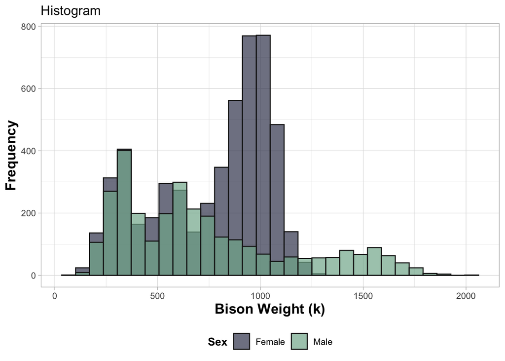

```r
knz_bison %>%
  plyr::mutate(animal_sex = revalue(animal_sex, c("F"= "Female", "M" = "Male"))) %>% # in plyr package, mutate values in animal sex column to spell out Female and Male
  ggplot(aes(x = animal_weight, fill = animal_sex)) +
  geom_histogram(color = "grey10",  position = "identity", alpha = .7) + # alpha increases transparency so you can see both groups
  scale_fill_manual(values = c("#3d405b", "#81b29a")) + # manually supply 2 colors to 2 groups
  theme_light() +
  labs(x = "Bison Weight (k)", y = "Frequency", fill = "Sex") +
  ggtitle("Histogram") +
  theme(axis.title = element_text(size = 14, face = "bold"),
        legend.title = element_text(face = "bold"),
        legend.position = "bottom") # distribution for female and male look different with females more left skew and males more right skew
```

## Exercise 2: Boxplot

Another way we can visualize the distribution of weight (**numeric**) by bison sex (**factor**) is with a **boxplot**. A boxplot visually represents the numeric distribution by factor/grouping. [data-to-vis](https://www.data-to-viz.com/caveat/boxplot.html) describes the elements of a box plots:

- The line that divides the box into 2 parts represents the **median** of the data. If the median is 10, it means that there are the same number of data points below and above 10
- The ends of the box shows the upper (Q3) and lower (Q1) quartiles. If the third quartile is 15, it means that 75% of the observation are lower than 15
- The difference between Quartiles 1 and 3 is called the interquartile range (IQR)
- The extreme line shows Q3+1.5xIQR to Q1-1.5xIQR (the highest and lowest value excluding outliers)
- Dots (or other markers) beyond the extreme line shows **potential outliers**

**Some questions we can answer with the following code**:

- **Based on the boxplot, how do the medians and dispersions compare between female and male bison?**
- **Based on the boxplot, do you see outliers?**

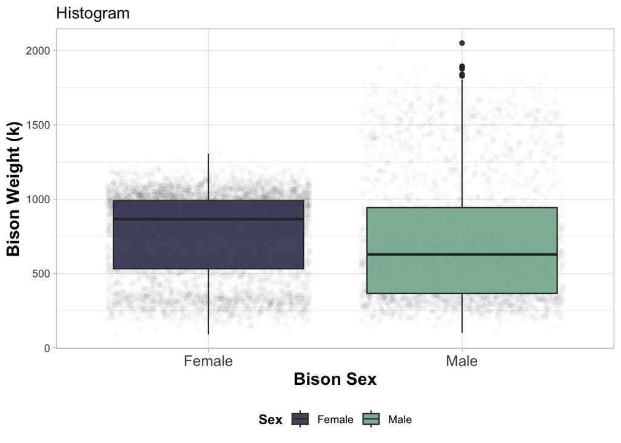

```r
knz_bison %>%
  plyr::mutate(animal_sex = revalue(animal_sex, c("F"= "Female", "M" = "Male"))) %>% # in plyr package, mutate values in animal sex column to spell out Female and Male
  ggplot(aes(x = animal_sex, y = animal_weight, fill = animal_sex)) +
  geom_jitter(alpha = .02, fill = "grey90")+ # add points behind geom_boxplot to get a better idea of the distribution of weight
  geom_boxplot(alpha = .9) + # increase the transparency of the boxplot to see points behind them
  scale_fill_manual(values = c("#3d405b", "#81b29a")) +
  theme_light() +
  labs(x = "Bison Sex", y = "Bison Weight (k)", fill = "Sex") +
  ggtitle("Histogram") +
  theme(axis.title = element_text(size = 14, face = "bold"),
        axis.text.x = element_text(size = 12),
        legend.title = element_text(face = "bold"),
        legend.position = "bottom") # The medians are not the same, with females on average having higher median value for weight (k) # The dispersion are not the same, with males on average having more variation (i.e. larger boxplot) # yes, males have individual bison outliers that are larger than the average male bison
```